# Exam 3

Trevor D. Millar

11/29/2020

To begin, we will load up the libraries that we will use. This includes tidyverse, modelr, and broom. Here we will also load up the data set for the first task and take a quick look at the first few rows to get a feel for the data.

```
##   FedID                  UnivName State Tier AvgFullProfSalary
## 1  1061 Alaska Pacific University    AK  IIB               454
## 2  1063     Univ.Alaska-Fairbanks    AK    I               686
## 3  1065     Univ.Alaska-Southeast    AK  IIA               533
## 4 11462     Univ.Alaska-Anchorage    AK  IIA               612
## 5  1002 Alabama Agri.&Mech. Univ.    AL  IIA               442
## 6  1004  University of Montevallo    AL  IIA               441
##   AvgAssocProfSalary AvgAssistProfSalary AvgProfSalaryAll AvgFullProfComp
## 1                382                 362              382             567
## 2                560                 432              508             914
## 3                494                 329              415             716
## 4                507                 414              498             825
## 5                369                 310              350             530
## 6                385                 310              388             542
##   AvgAssocProfComp AvgAssistProfComp AvgProfCompAll NumFullProfs NumAssocProfs
## 1              485               471            487            6            11
## 2              753               572            677           74           125
## 3              663               442            559            9            26
## 4              681               557            670          115           124
## 5              444               376            423           59            77
## 6              473               383            477           57            33
##   NumAssistProfs NumInstructors NumFacultyAll
## 1              9              4            32
## 2            118             40           404
## 3             20              9            70
## 4            101             21           392
## 5            102             24           262
## 6             35              2           127
```

## Task 1

This data set needs a lot of cleaning! Lets start by taking this data set from ‘wide’ format to ‘long’ format for the variables we are interested in. Specifically we need to look at a column with, the professional’s position (rank) and his or her salary. Because there are three positions listed, we will triple the length of our data frame when we do this pivot.

```r
columns_for_pivot <- c("AvgAssistProfSalary","AvgAssocProfSalary","AvgFullProfSalary")
df_long <- pivot_longer(df, cols = all_of(columns_for_pivot), names_to = "Rank",
                        values_to = "Salary", names_prefix = "Avg")
head(df_long)
```

```
## # A tibble: 6 x 16
##   FedID UnivName State Tier  AvgProfSalaryAll AvgFullProfComp AvgAssocProfComp
##   <int> <chr>    <chr> <chr>            <int>           <int>            <int>
## 1  1061 Alaska ~ AK    IIB                382             567              485
## 2  1061 Alaska ~ AK    IIB                382             567              485
## 3  1061 Alaska ~ AK    IIB                382             567              485
## 4  1063 Univ.Al~ AK    I                  508             914              753
## 5  1063 Univ.Al~ AK    I                  508             914              753
## 6  1063 Univ.Al~ AK    I                  508             914              753
## # ... with 9 more variables: AvgAssistProfComp <int>, AvgProfCompAll <int>,
## #   NumFullProfs <int>, NumAssocProfs <int>, NumAssistProfs <int>,
## #   NumInstructors <int>, NumFacultyAll <int>, Rank <chr>, Salary <int>
```

Our data frame seems a bit cluttered. We don’t need to use all of the information in the current analysis we can cut that down to only include the information we are interested in. We will, of course, keep our original data frame just in case we need it in a subsequent analysis. We also need to cut out the tier VIIB from the list, as it is not of interest in the present analysis. Lastly, it looks like we need to remove the suffixes from the x labels in order to cut back on all of the clutter.

```r
df_trimmed <- select(df_long, "UnivName", "State", "Tier", "Rank", "Salary")
df_trimmed$Rank <- as.factor(df_trimmed$Rank)
tiers_of_interest = c("I", "IIA", "IIB")
df_trimmed_selected <- filter(df_trimmed, Tier == "I" | Tier == "IIA" | Tier == "IIB")
df_trimmed_selected$Rank <- gsub("ProfSalary", "", df_trimmed_selected$Rank)
```

Here’s a look at the cleaned up data. What a sight!

```r
head(df_trimmed_selected)
```

```
## # A tibble: 6 x 5
##   UnivName                  State Tier  Rank   Salary
##   <chr>                     <chr> <chr> <chr>   <int>
## 1 Alaska Pacific University AK    IIB   Assist    362
## 2 Alaska Pacific University AK    IIB   Assoc     382
## 3 Alaska Pacific University AK    IIB   Full      454
## 4 Univ.Alaska-Fairbanks     AK    I     Assist    432
## 5 Univ.Alaska-Fairbanks     AK    I     Assoc     560
## 6 Univ.Alaska-Fairbanks     AK    I     Full      686
```

Lets take a look at our tidy-ed up data using GGplot

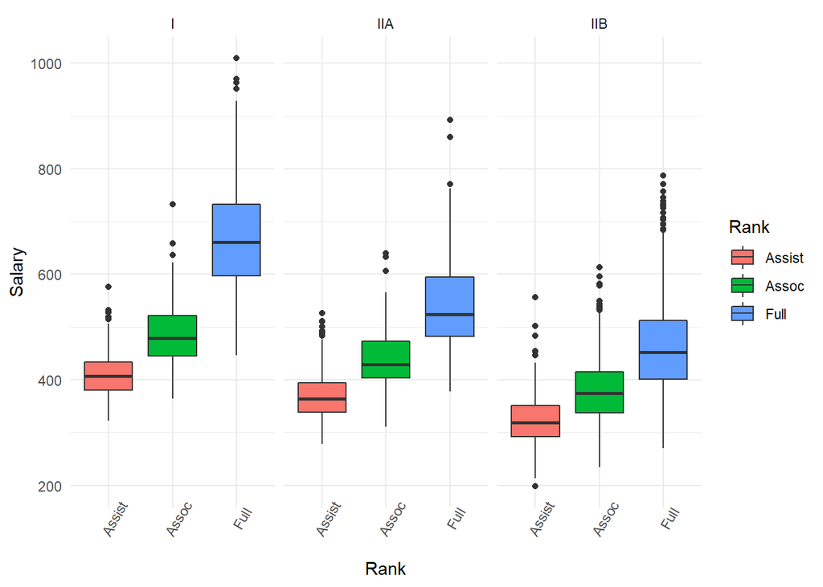

```r
p <- ggplot(df_trimmed_selected, aes(x = Rank, y = Salary, fill = Rank))+
  geom_boxplot() +
  theme_minimal() +
  facet_wrap(~Tier)+
  theme(axis.text.x = element_text(angle = 60))
p
```

```r
ggsave("MILLAR_Fig_1.jpg", p)
```

Not too bad! Those results should also have saved in your current working directory as MILLAR_Fig_1.jpg, think of it as a keep-sake. I hope you don’t mind.

## Task 2

Here we are going to take a look at an analysis of variance or ANOVA table for graphical results.

```r
Anova <- aov(Salary ~ State + Tier + Rank, data =  df_trimmed)
Anova_summary <- summary(Anova)
Anova_summary
```

```
##               Df   Sum Sq Mean Sq F value Pr(>F)
## State         51  5682396  111420   30.66 <2e-16 ***
## Tier           2  7072361 3536180  972.96 <2e-16 ***
## Rank           2 16529771 8264885 2274.04 <2e-16 ***
## Residuals   3299 11990072    3634
## ---
## Signif. codes:  0 '***' 0.001 '**' 0.01 '*' 0.05 '.' 0.1 ' ' 1
## 128 observations deleted due to missingness
```

```r
capture.output(Anova_summary, file = "./Salary_ANOVA_Summary.txt")
```

These results show that each of the three variables are significant (the difference in their mean values shows statistical significance across the board). This means, if you are considering a career in academia (and are motivated by money), you should try your best to get a job in a tier 1 school, work your way up to being a full time tenured professor, and think twice about what state you want to live in!

## Task 3

Let’s start by loading up the data and taking a peek. As usual, this data is probably going to need some tidying up. It’s a relatively complex data set, so lets just look at the column labels to save mental space.

```r
df_oils <- read.csv("Juniper_Oils.csv")
names(df_oils)
```

```
##  [1] "SampleID"               "Project"                "Amplicon"
##  [4] "Tree_Species"           "BurnYear"               "Latitude"
##  [7] "Longitude"              "Field_Office"           "BLM_Fire_Name"
## [10] "Tracking_Number"        "alpha.pinene"           "para.cymene"
## [13] "alpha.terpineol"        "cedr.9.ene"             "alpha.cedrene"
## [16] "beta.cedrene"           "cis.thujopsene"         "alpha.himachalene"
## [19] "beta.chamigrene"        "cuparene"               "compound.1"
## [22] "alpha.chamigrene"       "widdrol"                "cedrol"
## [25] "beta.acorenol"          "alpha.acorenol"         "gamma.eudesmol"
## [28] "beta.eudesmol"          "alpha.eudesmol"         "cedr.8.en.13.ol"
## [31] "cedr.8.en.15.ol"        "compound.2"             "thujopsenal"
## [34] "Yield_percent"          "Bolt_Surface_Area_cm2"  "Raw_Exit_Holes_per_cm2"
## [37] "Raw_Exit_Holes"         "Living_Larvae"          "ChemTotal"
## [40] "ChemMean"               "YearsSinceBurn"
```

As I expected, it looks like the data is in wide format and has a few other miscellaneous issues. Lets get this data into long format before anything else!

Dr. Zahn was kind enough to prepare a list of chemical names for us. In order to stump us though, he changed the format from “.” between the parts of the nomenclature into “-” between the parts of the nomenclature. Not to worry Dr. Zahn, we will just change the column names in our data set before we use your list of names as this is a line of code or two vs a lot of manual labor changing those names!

```r
names(df_oils) <- gsub("\\.", "-",names(df_oils))
names(df_oils)
```

```
##  [1] "SampleID"               "Project"                "Amplicon"
##  [4] "Tree_Species"           "BurnYear"               "Latitude"
##  [7] "Longitude"              "Field_Office"           "BLM_Fire_Name"
## [10] "Tracking_Number"        "alpha-pinene"           "para-cymene"
## [13] "alpha-terpineol"        "cedr-9-ene"             "alpha-cedrene"
## [16] "beta-cedrene"           "cis-thujopsene"         "alpha-himachalene"
## [19] "beta-chamigrene"        "cuparene"               "compound-1"
## [22] "alpha-chamigrene"       "widdrol"                "cedrol"
## [25] "beta-acorenol"          "alpha-acorenol"         "gamma-eudesmol"
## [28] "beta-eudesmol"          "alpha-eudesmol"         "cedr-8-en-13-ol"
## [31] "cedr-8-en-15-ol"        "compound-2"             "thujopsenal"
## [34] "Yield_percent"          "Bolt_Surface_Area_cm2"  "Raw_Exit_Holes_per_cm2"
## [37] "Raw_Exit_Holes"         "Living_Larvae"          "ChemTotal"
## [40] "ChemMean"               "YearsSinceBurn"
```

It’s looking good, but we need to compare this to the list of names Dr. Zahn uploaded.

```r
listed_chemicals <- c("alpha-pinene","para-cymene","alpha-terpineol","cedr-9-ene","alpha-cedrene","beta-cedrene","cis-thujopsene","alpha-himachalene","beta-chamigrene","cuparene","compound 1","alpha-chamigrene","widdrol","cedrol","beta-acorenol","alpha-acorenol","gamma-eudesmol","beta-eudesmol","alpha-eudesmol","cedr-8-en-13-ol","cedr-8-en-15-ol","compound 2","thujopsenal")
print(listed_chemicals)
```

```
##  [1] "alpha-pinene"      "para-cymene"       "alpha-terpineol"
##  [4] "cedr-9-ene"        "alpha-cedrene"     "beta-cedrene"
##  [7] "cis-thujopsene"    "alpha-himachalene" "beta-chamigrene"
## [10] "cuparene"          "compound 1"        "alpha-chamigrene"
## [13] "widdrol"           "cedrol"            "beta-acorenol"
## [16] "alpha-acorenol"    "gamma-eudesmol"    "beta-eudesmol"
## [19] "alpha-eudesmol"    "cedr-8-en-13-ol"   "cedr-8-en-15-ol"
## [22] "compound 2"        "thujopsenal"
```

We are close! I did notice that there is a discrepancy between “Compound 1” and “Compound-1” in the two lists. The same is true for compound 2. Lets fix that in the list of chemicals, because R doesn’t like working with spaces in column names.

```r
listed_chemicals <- gsub(" ","-", listed_chemicals)
print(listed_chemicals)
```

```
##  [1] "alpha-pinene"      "para-cymene"       "alpha-terpineol"
##  [4] "cedr-9-ene"        "alpha-cedrene"     "beta-cedrene"
##  [7] "cis-thujopsene"    "alpha-himachalene" "beta-chamigrene"
## [10] "cuparene"          "compound-1"        "alpha-chamigrene"
## [13] "widdrol"           "cedrol"            "beta-acorenol"
## [16] "alpha-acorenol"    "gamma-eudesmol"    "beta-eudesmol"
## [19] "alpha-eudesmol"    "cedr-8-en-13-ol"   "cedr-8-en-15-ol"
## [22] "compound-2"        "thujopsenal"
```

Alright, we can finally get into pivoting our data-set into long format. We’re going to take the liberties of cleaning the dataset further by just removing the variables that aren’t going to be used in this analysis.

```r
df_oils_trimmed <- select(df_oils, "YearsSinceBurn", all_of(listed_chemicals))

df_oils_trimmed_long <- pivot_longer(df_oils_trimmed, cols = listed_chemicals, names_to = "Compound", values_to = "Concentration")

head(df_oils_trimmed_long)
```

```
## # A tibble: 6 x 3
##   YearsSinceBurn Compound        Concentration
##            <int> <chr>                   <dbl>
## 1              2 alpha-pinene              0.6
## 2              2 para-cymene               0.4
## 3              2 alpha-terpineol           2.3
## 4              2 cedr-9-ene                0.2
## 5              2 alpha-cedrene             1.9
## 6              2 beta-cedrene              1.2
```

It looks like our data set is roaring and ready to go!

## Task 4

Let’s make a nice GGplot of our data. We’re going to plot the concentration of oils as a function of years since the forest fire that killed the tree. Also, each chemical that was observed in the analysis is going to have its own facet so that we can see individual results. Mind you that the y-axis scales are different for each facet!

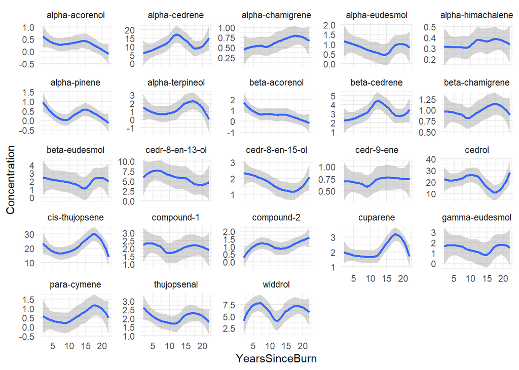

```r
oils_plot <- ggplot(df_oils_trimmed_long, aes(x = YearsSinceBurn, y = Concentration))+
  facet_wrap(~Compound, scales = "free_y")+
  theme_minimal()+
  geom_smooth()
oils_plot
```

```r
ggsave("MILLAR_Fig_2.jpg", oils_plot)
```

## Task 5

As a side note, we are using scipen = 999 in order to see our results in normal (non-scientific) notation.

```r
#Generate prescribed model
options(scipen = 999)
mod1 <- glm(data = df_oils_trimmed_long, Concentration ~ YearsSinceBurn + Compound)
#Make it into a tidy tibble table
tidytable <- tidy(mod1)
tidytable
```

```
## # A tibble: 24 x 5
##    term                      estimate std.error statistic  p.value
##    <chr>                        <dbl>     <dbl>     <dbl>    <dbl>
##  1 (Intercept)                0.220      0.684     0.321  7.48e- 1
##  2 YearsSinceBurn             0.00470    0.0208    0.225  8.22e- 1
##  3 Compoundalpha-cedrene     10.6        0.899    11.8    1.13e-29
##  4 Compoundalpha-chamigrene   0.359      0.899     0.399  6.90e- 1
##  5 Compoundalpha-eudesmol     0.594      0.899     0.661  5.09e- 1
##  6 Compoundalpha-himachalene  0.0706     0.899     0.0785 9.37e- 1
##  7 Compoundalpha-pinene       0.0235     0.899     0.0262 9.79e- 1
##  8 Compoundalpha-terpineol    0.953      0.899     1.06   2.90e- 1
##  9 Compoundbeta-acorenol      0.306      0.899     0.340  7.34e- 1
## 10 Compoundbeta-cedrene       2.78       0.899     3.09   2.09e- 3
## # ... with 14 more rows
```

That’s a lot of information to look at in my opinion and in all reality the only values we are interested in are those which are statistically significant (p < 0.05). Let’s filter for only those results. We also have a formatting issue with the compound names we should fix (did you notice the prefix “Compound” added to each name?)

```r
#Filter this tidy tibble table for significant p values
tidytable_filtered <- filter(tidytable, p.value < 0.05)

# Format issue with the names of compounds. Need to remove prefix "compound"
tidytable_filtered$term <- gsub("Compound","",tidytable_filtered$term)
tidytable_filtered
```

```
## # A tibble: 10 x 5
##    term            estimate std.error statistic  p.value
##    <chr>              <dbl>     <dbl>     <dbl>    <dbl>
##  1 alpha-cedrene      10.6      0.899     11.8  1.13e-29
##  2 beta-cedrene        2.78     0.899      3.09 2.09e- 3
##  3 beta-eudesmol       1.79     0.899      1.99 4.71e- 2
##  4 cedr-8-en-13-ol     5.55     0.899      6.17 1.08e- 9
##  5 cedrol             19.8      0.899     22.0  1.40e-83
##  6 cis-thujopsene     21.3      0.899     23.7  3.09e-93
##  7 compound-1          1.82     0.899      2.02 4.36e- 2
##  8 cuparene            1.92     0.899      2.14 3.28e- 2
##  9 thujopsenal         1.79     0.899      1.99 4.71e- 2
## 10 widdrol             6.14     0.899      6.82 1.84e-11
```